# Quick Reminder

Alejandra Medina-Rivera

2018-07-28

# Access R

- R can be accessed through the command line
- Emacs has a package to communicate with R, Emacs Speaks Statistics
- R can be accessed through a Graphic User Interface We will be using [Rstudio](https://www.rstudio.com/)

# Some basic notes

## Operators in R

| Operator | Description |
| --- | --- |
| + | addition |
| - | subtraction |
| * | multiplication |
| / | division |
| ** or ^ | exponential |
| > | greater than |
| >= | greater than or equal to |
| == | equal to |
| != | not equal to |

# Data Types

In R, the basic data types are vectors, not scalars A vector contains an index set of values that are all of the same type: * logical * numeric * complex * character

The numeric type can be further broken down into integer, single, and double types (but this important when making calls to foreign functions, e.g. C or FORTRAN)

## Data Structures

The principal data structures in R are: * vector- array of objects of the same type * matrix- array of vectors * list- can contain objects of different types * environment- hash table * data.frame-array of vectors, lists or both. * factor- categorical * function Packages as [Bioconductor](https://www.bioconductor.org/) provide other types of data structures.

## Declaring variables

The operators to create variables are **<-** and **=**

```r
v1 <- c(1:10)
v1
```

```
 [1]  1  2  3  4  5  6  7  8  9 10
```

```r
v2 <- runif(10)
v2
```

```
 [1] 0.50911395 0.80626109 0.80217165 0.37190474 0.05545797 0.58760542
 [7] 0.41214924 0.25135025 0.67329828 0.42298860
```

```r
v3 <- sample(c("A", "C", "G", "T"),
    size = 10, replace = TRUE)
v3
```

```
 [1] "G" "A" "G" "A" "C" "A" "C" "C" "A" "G"
```

```r
v4 <- v3 %in% c("A", "G")
v4
```

```
 [1]  TRUE  TRUE  TRUE  TRUE FALSE  TRUE FALSE FALSE  TRUE  TRUE
```

```r
v5 <- c("foo", 2, TRUE)
v5
```

```
[1] "foo"  "2"    "TRUE"
```

```r
v6 <- c(2, "3")
v6
```

```
[1] "2" "3"
```

## Install pacakges

For the sake of this course it is required to install some packages.

```r
install.packages("devtools", "roxygen2", "Rcpp", "RcppArmadillo", "knitr")
install.packages("ISwR")
```

## Control Structures

- if is the most simple control structure, and usage is simple: if (cond1=vdd) {cmd1} else {cmd2}
- ifelse, usage: ifelse(test, vaue-true, value-false)

```r
 if (1 == 0) {  print(1)  } else {
print(2) }
```

```
[1] 2
```

```r
x <- 1:10
ifelse(x < 5 | x > 8, x, 0)
```

```
 [1]  1  2  3  4  0  0  0  0  9 10
```

## Input data

- There are several functions in R to read in data from a file
  - scan()
  - read.table()
  - read.csv()
  - source().
- Remember, to learn more: help(read.csv)
- scan() is useful when you don???t know the structure of your data..
- source() command used to read scripts R and execute them inside the current session.

# Cycling

## Basic cycling commands

- **while** Usage: while(condition) {…}

```r
y <- 12345
x <- y/2
x
```

```
[1] 6172.5
```

```r
while (abs(x * x - y) > 1e-10)
{
  x <- (x + + y/x)/2
  }
x
```

```
[1] 111.1081
```

```r
x^2
```

```
[1] 12345
```

- **for** Usage: for(variable in sequence) {…}

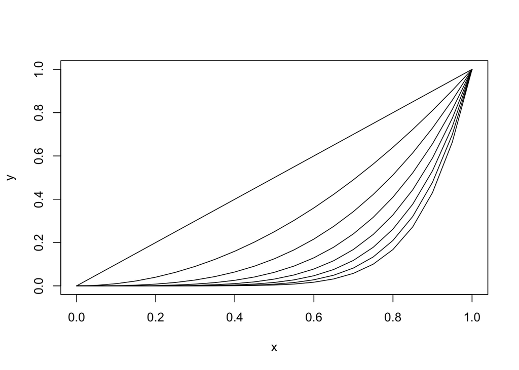

```
logical(0)
```

```r
x <- seq(0, 1, 0.05)
plot(x, x, ylab = "y", type = "l") > for (j in 2:8) {
lines(x, x^j)
}
```

## Apply

A common application of loops is to apply a function to each element of a set of values or vectors and collect the results in a single structure.

In R this is abstracted by the family of apply functions. For example: * lapply, returns a list. * sapply, simplifies the result to a vector or a matrix if possible.

```r
library(ISwR)
data( thuesen )
head(thuesen)
```

```
  blood.glucose short.velocity
1          15.3           1.76
2          10.8           1.34
3           8.1           1.27
4          19.5           1.47
5           7.2           1.27
6           5.3           1.49
```

```r
lapply(thuesen, mean, na.rm = T)
```

```
$blood.glucose
[1] 10.3

$short.velocity
[1] 1.325652
```

```r
sapply(thuesen, mean, na.rm = T)
```

```
 blood.glucose short.velocity
     10.300000       1.325652
```

Why these and not explicit loops?

- These functions attach meaningful names to the results
- When correctly used they tend to be faster

An other function of this family is apply, which allows you to apply a function to the row or the columns of a matrix

```r
m <- matrix(rnorm(12), 4)
m
```

```
           [,1]       [,2]       [,3]
[1,]  0.6922498 -0.8575667 -2.4215350
[2,]  0.7069854 -0.1487841  0.1836851
[3,] -0.5945557  0.4016977  1.0311848
[4,] -1.3613974  1.6299320 -0.6857620
```

```r
apply(m, 2, min)
```

```
[1] -1.3613974 -0.8575667 -2.4215350
```

# Functions

- Functions are objects of type function and all functions in R as mean are of the same type.
- Functions are defined as: mifun <- function(arg1, arg2, …) { What the function will do}
- Functions are called with: mifun(arg1 = …, arg2 = …)
- Is better if all arguments have a default value ex: arg1 = val.def. When a function is called, the arguments can be set in the same order these are defined in the function, or you can use their tag (names)
- Inside the function there can be one or several instructions.
- The returned value of a function is the last one to be evaluated or the one defined with return.

```r
fact <- function(x = 1) {
  ret <- 1
  for (i in 1:x) {
    ret <- ret *i
  }
  return(c(x,ret))
}
fact()
```

```
[1] 1 1
```

```r
fact(x=5)
```

```
[1]   5 120
```

```r
fact(6)
```

```
[1]   6 720
```

## Control

- In R there are three control functions that can be used within function to regulate how they work
  - **return**: specifies the value that has to be returned and ends the function.
  - **stop**: stops the function and prints an error message.
  - **warning**: prints a message but doesn’t stop the function.

```r
myfun <- function(x1){
  if (x1 > 0) {
    print (x1)
    }
else if (x1 == 0) {
  warning("Value must be > 0")
  }
else{
  stop ("There is a problem, x1 < 0 ")
  }
}
```

```r
myfun(x1=0)
myfun(x1=2)
```

[output not shown]

## References

- [Introductory Statistics with R, Dalgaard, Peter, Springer](https://www.springer.com/us/book/9780387790534)